# d_clean slides

### Exercício 130 — Jitter em pacotes de voz

Em uma rede, 70% dos pacotes são de voz. O jitter ocorre com:

- 10% nos pacotes de voz
- 5% nos demais pacotes

Tarefas:

- Calcule a probabilidade de um pacote ter jitter.
- Calcule a probabilidade de ser voz dado que teve jitter.

#### Definições

- $V$: pacote é de voz
- $\bar{V}$: pacote não é de voz
- $J$: ocorre jitter

#### Probabilidades conhecidas

- $P(V) = 0.70$
- $P(\bar{V}) = 0.30$
- $P(J \mid V) = 0.10$
- $P(J \mid \bar{V}) = 0.05$

#### 1. Probabilidade de jitter: $P(J)$

Aplicando a fórmula da probabilidade total:

$$ P(J) = P(J \mid V) \cdot P(V) + P(J \mid \bar{V}) \cdot P(\bar{V}) $$$$ P(J) = 0.10 \cdot 0.70 + 0.05 \cdot 0.30 = 0.07 + 0.015 = \boxed{0.085} $$

#### 2. Probabilidade de ser voz dado que houve jitter: $P(V \mid J)$

Pelo teorema de Bayes:

$$ P(V \mid J) = \frac{P(J \mid V) \cdot P(V)}{P(J)} = \frac{0.10 \cdot 0.70}{0.085} = \frac{0.07}{0.085} = \boxed{0.8235} $$

#### Conclusão

- A probabilidade de um pacote ter jitter é $P(J) = 0.085$
- A probabilidade de ser pacote de voz dado que teve jitter é $P(V \mid J) = 0.8235$

Durante uma análise de latência em redes 5G, um engenheiro coletou uma amostra de 10 medições com média de 21 ms, enquanto o valor real da média populacional conhecida é 20 ms.

**Tarefas:**

- Calcule o erro amostral.
- Explique a diferença entre erro amostral e erro residual no contexto dessa rede.

**Erro amostral:**  
$E_{\bar{x}} = \bar{x} - \mu = 21 - 20 = 1\ \text{ms}$

A interpretação desse resultado destaca que, ao considerar a população completa (todas as possíveis medições), qualquer subconjunto extraído (isto é, uma amostra) pode apresentar um desvio em relação à média verdadeira — este desvio é o **erro amostral**.

Enquanto o **erro amostral** é a diferença entre a média de uma amostra e a média real da população, o **erro residual** é a diferença entre um valor observado e o valor previsto por um modelo de ajuste. Ou seja, ele mede **o quanto cada observação individual se afasta da predição do modelo**.

**Erro residual:**  
$e_i = y_i - \hat{y}_i$

Já o **erro padrão da média**, denotado por $\sigma_{\bar{x}}$, representa a variabilidade esperada do erro amostral $E_{\bar{x}}$ ao longo de várias amostras. Ele é dado por:

$\sigma_{\bar{x}} = \dfrac{\sigma}{\sqrt{n}}$

Esse erro padrão é utilizado para construir intervalos de confiança para a média populacional. Quando a distribuição da média amostral é aproximadamente normal, temos:

$\bar{x} \pm z \cdot \dfrac{\sigma}{\sqrt{n}}$

> Quando $\sigma$ não é conhecido, usamos o desvio padrão amostral $s$ no lugar de $\sigma$.

Abaixo, temos um gráfico que representa os valores de $z$ que delimitam a área central da curva normal padrão, de forma a conter 90% ou 95% da distribuição. Esses valores de $z$ são usados para construir intervalos de confiança para a média amostral, garantindo que, com 90% ou 95% de confiança, a média populacional esteja dentro do intervalo calculado a partir da amostra.

**agg_record_172009442:** 2

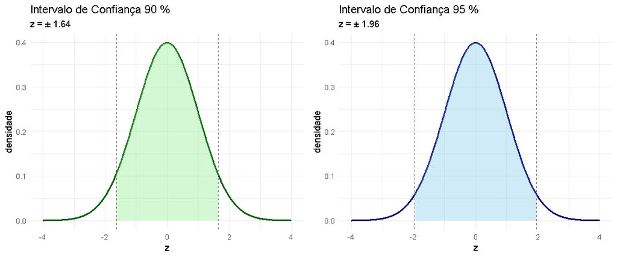

**Figura:** comparação dos intervalos de confiança de 90% e 95% sob a curva normal padrão. O intervalo de 95% (à direita) é mais amplo, refletindo maior nível de confiança à custa de um maior valor crítico de $z$. O intervalo de 90% (à esquerda) é mais estreito, resultando em menor valor crítico e menor cobertura.

```r
library(ggplot2)
library(gridExtra)
library(base64enc)
library(IRdisplay)

# Função para gerar gráfico com curva normal e intervalo sombreado com cores customizáveis
plot_z_conf <- function(z, conf_level, curva_color, sombra_color) {
  x <- seq(-4, 4, length.out = 1000)
  y <- dnorm(x)
  df <- data.frame(x = x, y = y)
  shade <- subset(df, x >= -z & x <= z)

  ggplot(df, aes(x, y)) +
    geom_line(color = curva_color, linewidth = 1.2) +
    geom_area(data = shade, aes(x, y), fill = sombra_color, alpha = 0.4) +
    geom_vline(xintercept = c(-z, z), linetype = "dashed", color = "gray40") +
    labs(
      title = paste("Intervalo de Confiança", conf_level, "%"),
      subtitle = paste("z = ±", z),
      x = "z", y = "densidade"
    ) +
    theme_minimal(base_size = 13)
}

# Criar os dois gráficos com cores distintas
g90 <- plot_z_conf(1.64, 90, curva_color = "darkgreen", sombra_color = "lightgreen")
g95 <- plot_z_conf(1.96, 95, curva_color = "navy", sombra_color = "skyblue")

# Salvar imagem temporária com os dois gráficos lado a lado
tmpfile <- tempfile(fileext = ".png")
png(tmpfile, width = 1200, height = 500, res = 100)
grid.arrange(g90, g95, ncol = 2)
dev.off()

# Converter para base64
img_b64 <- dataURI(file = tmpfile, mime = "image/png")

# Exibir centralizado no notebook
display_html(sprintf('
<div style="text-align:center; max-width: 100%%;">
  <img src="%s" style="max-width: 100%%; height: auto;">
  <div style="margin-top:8px; font-size:90%%; color:#555; text-align:justify;">
    <b>Figura:</b> comparação dos intervalos de confiança de 90%% e 95%% sob a curva normal padrão.
    O intervalo de 95%% (à direita) é mais amplo, refletindo maior nível de confiança à custa de um maior valor crítico de $z$.
    O intervalo de 90%% (à esquerda) é mais estreito, resultando em menor valor crítico e menor cobertura.
  </div>
</div>
', img_b64))
```